# Bayesian data analysis

## The road ahead

### theory

- posterior inference & credible values
- Bayes factors & model comparison
- comparison of Bayesian and "classical" NHST

### practice

- basics of MCMC sampling
- tools for BDA ( JAGS, Stan, WebPPL, Jasp, rstanarm)
- Bayesian cognitive modeling example

## sampling from the posterior

## key notions

- Markov Chain Monte Carlo methods
  - Metropolis Hastings
  - Gibbs
  - Hamiltonian MC
- convergence / representativeness
  - trace plots
  - \(\hat{R}\)
- efficiency
  - autocorrelation
  - effective sample size

## recap

### Bayes rule for data analysis:

\[\underbrace{P(\theta \, | \, D)}_{posterior} \propto \underbrace{P(\theta)}_{prior} \times \underbrace{P(D \, | \, \theta)}_{likelihood}\]

normalizing constant:

\[ \int P(\theta') \times P(D \mid \theta') \, \text{d}\theta' = P(D) \]

### problem

how to calculate for unwieldy models with high-dimensional \(\theta\)?

## approximation by sampling

[interactive chart not shown]

## problem statement

### notation

- \(X = (X_1,\dots,X_k)\) is a vector of random variables
- true distribution of \(X\) is \(P\)

### desideratum

an efficient way of getting samples \(x \sim P\) without access to \(P\) itself

## Markov chain

### intuition

- a sequence of elements from \(X\), \(x_0, x_1, \dots, x_n\) such that every \(x_{i+1}\) depends only on its predecessor \(x_i\)
  - think: probabilistic finite state machine

[figure not shown]

### Markov property

\[P(X_{n+1} = x_{n+1} \mid X_0 = x_0, \dots, X_n = x_n) = P(X_{n+1} = x_n \mid X_n = x_n)\]

## Markov Chain Monte Carlo methods

### idea

- get sequence of samples \(x\) s.t. every sample depends only on predecessor
- the stationary distribution of the chain is \(P\)
- in the limit, then, \(x\) are representative samples of \(P\), \(x \sim P\)

dummy

### benefits & pitfalls

good

- can approximate any distribution
- no need for normalizing constant
- only prior and likelihood required

bad

- may take a while
- autocorrelation
- best MCMC algo depends on case

## Metropolis Hastings

## island hopping

[figure not shown]

- set of islands \(X = \{x_1, x_2, \dots x_n\}\)
- goal: hop around & visit every island \(x_i\) proportional to its population \(P(x_i)\)
  - think: "samples" from \(x \sim P\)
- problem: island hopper can remember at most 2 islands' population
  - think: we don't know the normalizing constant

## Metropolis Hastings

- let \(f(x) = \alpha P(x)\) (e.g., unnormalized posterior)
- start at random \(x^0\), define probability \(P_\text{trans}(x^i \rightarrow x^{i+1})\) of going from \(x^{i}\) to \(x^{i+1}\)
  - proposal \(P_\text{prpsl}(x^{i+1} \mid x^i)\): prob. of considering jump to \(x^{i+1}\) from \(x^{i}\)
  - acceptance \(P_\text{accpt}(x^{i+1} \mid x^i)\): prob of making jump when \(x^{i+1}\) is proposed \[P_\text{accpt}(x^{i+1} \mid x^i) = \text{min} \left (1, \frac{f(x^{i+1})}{f(x^{i})} \frac{P_\text{prpsl}(x^{i} \mid x^{i+1})}{P_\text{prpsl}(x^{i+1} \mid x^i)} \right)\]
  - transition \(P_\text{trans}(x^i \rightarrow x^{i+1}) = P_\text{prpsl}(x^{i+1} \mid x^i) \times P_\text{accpt}(x^{i+1} \mid x^i)\)

## properties MH

- motto: always up, down with probability \(\frac{f(x^{i+1})}{f(x^{i})}\)
- ratio \(\frac{f(x^{i+1})}{f(x^{i})}\) means that we can forget about normalizing constant
- \(P_\text{trans}(x^i \rightarrow x^{i+1})\) defines transition matrix -> Markov chain analysis!
- for suitable proposal distributions:
  - stationary distribution exists (first left-hand eigenvector)
  - every initial condition converges to stationary distribution
  - stationary distribution is \(P\)

## influence of proposal distribution

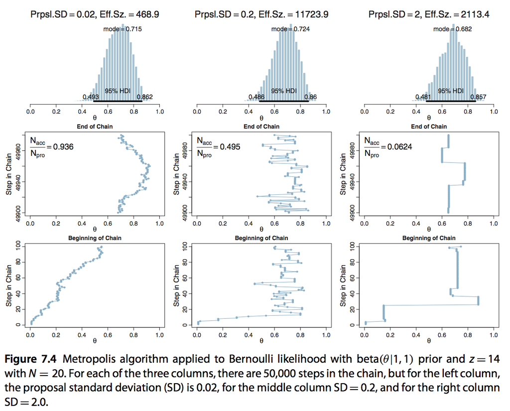

## Gibbs sampling

## Gibbs sampling: introduction

- Metropolis is a very general and versatile algorithm
- however in specific situations, other algorithms may be better applicable
- for example, if \(X=(X_1,\dots,X_k)\) is a vector of random variables and \(P(x)\) is a multidimensional distribution
- in such cases, the Gibbs sampler may be helpful
- basic idea: split the multidimensional problem into a series of simpler problems of lower dimensionality

## Gibbs sampling: main idea

- assume \(X=(X_1,X_2,X_3)\) and \(p(x)=P(x_1,x_2,x_3)\)
- start with \(x^0=(x_1^0,x_2^0,x_3^0)\)
- at iteration \(t\) of the Gibbs sampler, we have \(x^{i-1}\) and need to generate \(x^{i}\)
  - \(x_1^{i} \sim P(x_1 \mid x_2^{i-1},x_3^{i-1})\)
  - \(x_2^{i} \sim P(x_2 \mid x_1^{i},x_3^{i-1})\)
  - \(x_3^{i} \sim P(x_3 \mid x_1^{i},x_2^{i})\)
- for a large \(n\), \(x^n\) will be a sample from \(P(x)\)
  - \(x^n_k\) will be a sample from \(P(x_k)\) (marginal distribution)

## example: Gibbs for 2 coin flips

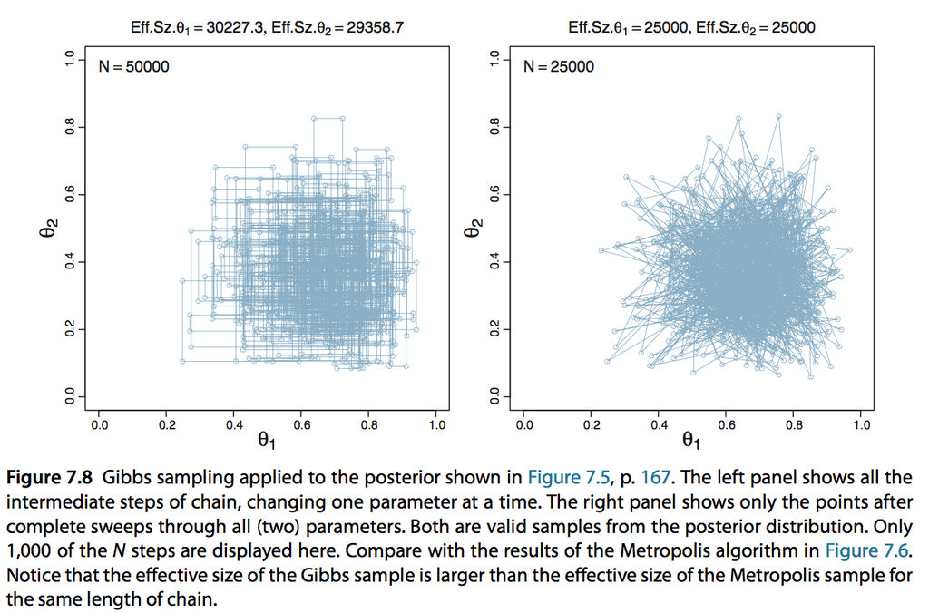

## example: MH for 2 coin flips

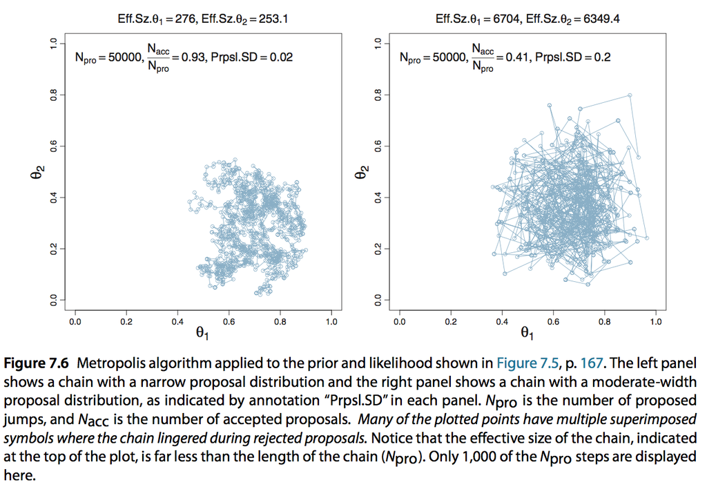

## summary

- Gibbs sampling can be more efficient than MH
- Gibbs needs samples from conditional posterior distribution
  - MH is more generally applicable
- preformance of MCMC algorithms depends on proposal distribution
- clever software helps determines which algorithm to use and how to fine-tune it

## Hamiltonian MC

## Hamiltonian motion

- Hamiltonian movement
  - reformulates classical mechanics
  - precursor of statistical physics
  - closed system differential equations
  - potential vs. kinetic energy

[figure not shown]

dummy dummy dummy

potential

[figure not shown]

kinetic

[figure not shown]

## example

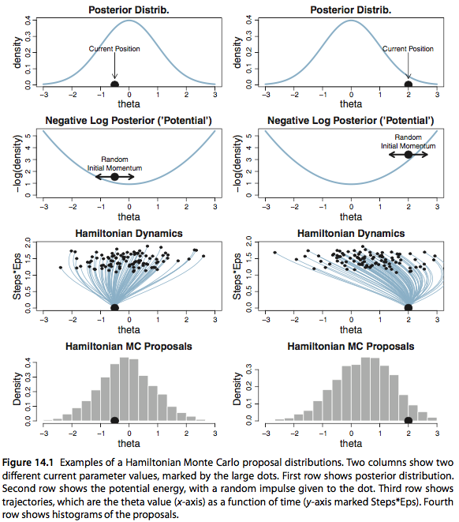

## tuning parameters

- momentum
  - e.g., standard deviation of Gaussian that determines initial jiggle

dummy

- step size
  - how big a step to take in discretization of gradient

dummy

- number of steps
  - how many steps before producing the proposal

## assessing sample chains

## problem statements

### convergence/representativeness

- we have samples from MCMC, ideally several chains
- in the limit, samples must be representative of \(P\)
- how do we know that our meagre finite samples are representative?

### efficiency

- ideally, we'd like as small a sample set as possible
- how do we measure that we have "enough" samples?

## examining sample chains: beginning

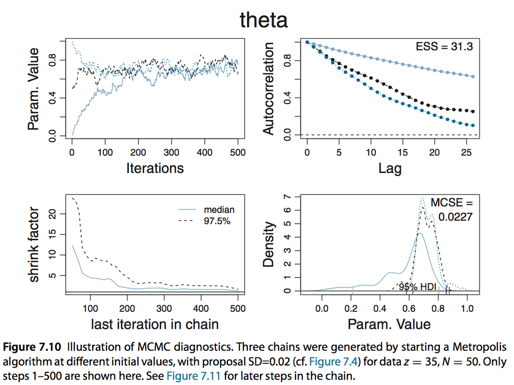

## examining sample chains: rest

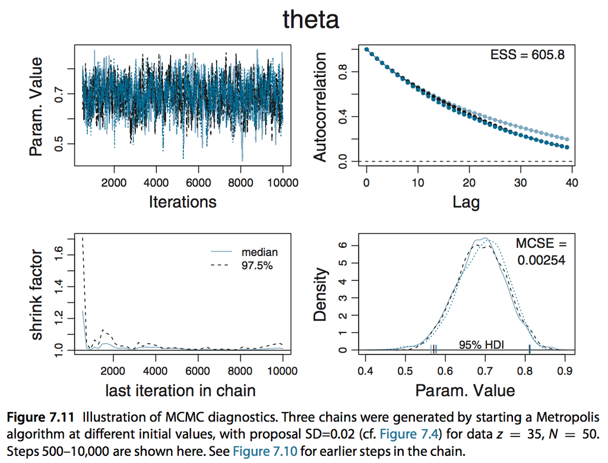

## \(\hat{R}\)

\(\hat{R}\)-statistics

- a.k.a.:
  - Gelman-Rubin statistics
  - shrink factor
  - potential scale reduction factor
- idea:
  - compare variance within a chain to variance between chains
  - [think: ANOVA]
- in practice:
  - use software to compute it
  - aim for \(\hat{R} \le 1.1\) for all continuous variables

## autocorrelation

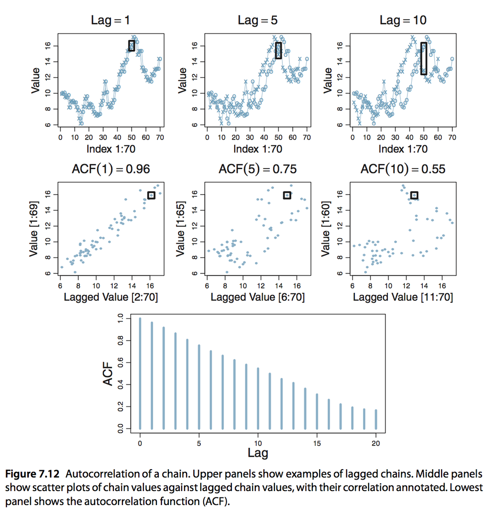

## effective sample size

- intuition:
  - how many samples are "efficient, actual samples" if we strip off autocorrelation
- definition:

\[\text{ESS} = \frac{N}{ 1 + 2 \sum_{k=1}^{\infty} ACF(k)}\]

## tools for Bayesian inference

## overview

|  | JAGS | Stan | WebPPL |
| --- | --- | --- | --- |
| flavor | declarative | imperative | functional |
| feels like | BUGS + R | BUGS + C | JavaScript |
| methods | MH, Gibbs, … | HMC, variational, … | MH, MHM, rejection, … |
| interfaces | R, Python, Matlab | R, Python, Matlab, … | R, (…?) |
| goodies |  | rstanarm, loo | browser-based |
| developers | [Martyn Plummer](https://www.iarc.fr/en/staffdirectory/displaystaff.php?id=10118) | [Stan Dev. Team (Gelman, Carpenter, …)](http://mc-stan.org/team/) | [N. Goodman & A. Stuhlmüller et al.](http://cocolab.stanford.edu/index.html) |
| websites | [JAGS](http://mcmc-jags.sourceforge.net) | [Stan](http://mc-stan.org) | [WebPPL](http://webppl.org) |

## JAGS

## overview

- declarative model specification
  - model as a directed acyclic graph / Bayes nets
    - nodes are variables, edges are deterministic or probabilistic dependencies
  - order invariant
  - no variable reassignment, no control flow statements etc.
    - exception: "ifelse" and "step" commands for boolean switching
    - "for"-loops for vector construction
- automatically selects adequate sampler
- call from & process output, e.g., in R via packages:
  - R2Jags
  - rjags
  - runjags

## example

```r
require('rjags')
modelString = "
model{
  theta ~ dbeta(1,1)
  k ~ dbinom(theta, N)
}"
# prepare for JAGS
dataList = list(k = 14, N = 20)
# set up and run model
jagsModel = jags.model(file = textConnection(modelString),
                       data = dataList,
                       n.chains = 2)
update(jagsModel, n.iter = 5000)
codaSamples = coda.samples(jagsModel,
                           variable.names = c("theta"),
                           n.iter = 5000)
```

## example

```r
require('ggmcmc')
require('dplyr')
ms = ggs(codaSamples)
ms %>% group_by(Parameter) %>%
   summarise(mean = mean(value),
             HDIlow  = HPDinterval(as.mcmc(value))[1],
             HDIhigh = HPDinterval(as.mcmc(value))[2])
```

```
## # A tibble: 1 × 4
##   Parameter      mean    HDIlow   HDIhigh
##      <fctr>     <dbl>     <dbl>     <dbl>
## 1     theta 0.6814352 0.4967396 0.8756536
```

## example

```r
  tracePlot = ggs_traceplot(ms)
  densPlot = ggs_density(ms) +
    stat_function(fun = function(x) dbeta(x, 15,7), color = "black")
```

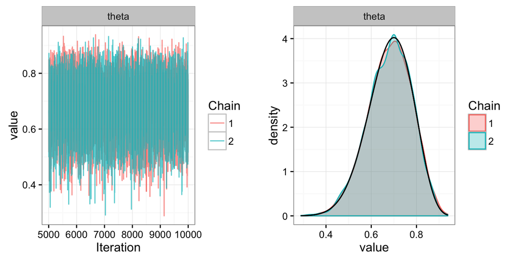

```r
  require('gridExtra')
  grid.arrange(tracePlot, densPlot, ncol = 2)
```

## another example

Your turn: what's this model good for?

- `obs` is a vector of 100 observations (real numbers)

```r
model{
  mu ~ dunif(-2,2)
  var ~ dunif(0, 100)
  tau = 1/var
  for (i in 1:100){
    obs[i] ~ dnorm(mu,tau)
  }
}
```

NB: JAGS' precision \(\tau = 1/\sigma^2\), not standard deviation \(\sigma\) in `dnorm`

## model specifications, formally

```r
model{
  mu ~ dunif(-2,2)
  var ~ dunif(0, 100)
  tau = 1/var
  for (i in 1:100){
    obs[i] ~ dnorm(mu,tau)
  }
}
```

\[\mu \sim \text{Unif}(-2,2)\] \[\sigma^2 \sim \text{Unif}(0,100)\] \[obs_i \sim \text{Norm}(\mu, \sigma)\]

## Stan

## background

- [mc-stan.org](http://mc-stan.org/)
- actively developed by Andrew Gelman, Bob Carpenter and others
- uses HMC and NUTS, but can do variational Bayes and MAP too
- written in C++
- cross-platform
- interfaces: command line, Python, Julia, R, Stata, Matlab

## example: JAGS vs. Stan

```r
require('rjags')
ms = "
model{
  theta ~ dbeta(1,1)
  k ~ dbinom(theta, N)
}"
# prepare data for JAGS
dataList = list(k = 14, N = 20)
# set up and run model
jagsModel = jags.model(
  file = textConnection(ms),
  data = dataList, n.chains = 2)
update(jagsModel, n.iter = 5000)
codaSamples = coda.samples(
  jagsModel,
  variable.names = c("theta"),
  n.iter = 5000)
```

```r
require('rstan')
ms = "
data {
  int<lower=0> N ;
  int<lower=0> k ;
}
parameters {
  real<lower=0,upper=1> theta ;
}
model {
  theta ~ beta(1,1) ;
  k ~ binomial(N, theta) ;
}"
# prepare data for Stan
dataList = list(k = 14, N = 20)
# set up and run
mDso = stan_model(model_code = ms)
stanFit = sampling(object = mDso,
  data = dataList,
  chains = 2,
  iter = 10000,
  warmup = 5000)
```

## Stan output

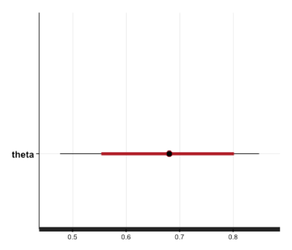

```r
plot(stanFit)
```

## data wrangling

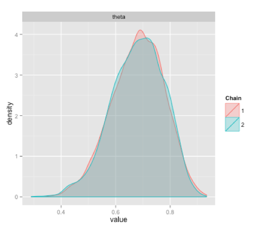

```r
codaSamples = As.mcmc.list(stanFit)
ms = ggs(stanFit)
ggs_density(ms)
```

## discrete latent parameters in Stan

### problem

- Stan needs gradients / derivatives
  - cannot infer discrete latent parameters

dummy

### solution

- marginalize out

## Exam scores

15 people answered 40 exam questions. Here's their scores:

```r
k <- c(21,17,21,18,22,31,31,34,34,35,35,36,39,36,35)
p <- length(k) #number of people
n <- 40 # number of questions
```

- assume that some guessed randomly, others gave informed answers
- who is a guesser?
- what's the probability of correct answering for non-guessers?

dummy dummy dummy dummy dummy dummy

[from Lee & Wagenmakers (2015), Chapter 6.1]

## JAGS model

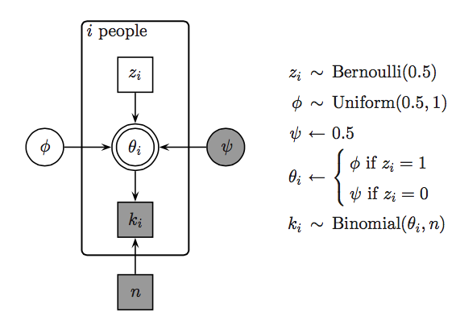

```r
model{
  for (i in 1:p){
    z[i] ~ dbern(0.5)
  }
  psi = 0.5
  phi ~ dunif(0.5,1)
  for (i in 1:p){
    theta[i] = ifelse(z[i]==0,psi,phi)
    k[i] ~ dbin(theta[i],n)
  }
}
```

## JAGS model: results

```r
k <- c(21,17,21,18,22,31,31,34,34,35,35,36,39,36,35)
show(summary(codaSamples)[[1]][,1:2])
```

```
##           Mean         SD
## phi   0.863443 0.01719438
## z[1]  0.000000 0.00000000
## z[2]  0.000000 0.00000000
## z[3]  0.000000 0.00000000
## z[4]  0.000000 0.00000000
## z[5]  0.000000 0.00000000
## z[6]  0.992200 0.08797689
## z[7]  0.994500 0.07396146
## z[8]  1.000000 0.00000000
## z[9]  0.999900 0.01000000
## z[10] 1.000000 0.00000000
## z[11] 1.000000 0.00000000
## z[12] 1.000000 0.00000000
## z[13] 1.000000 0.00000000
## z[14] 1.000000 0.00000000
## z[15] 1.000000 0.00000000
```

## Stan model

```c
data {
  int<lower=1> p;  int<lower=0> k[p];   int<lower=1> n;
}
transformed data {
  real psi; psi <- .5;
}
parameters {
  real<lower=.5,upper=1> phi;
}
transformed parameters {
  vector[2] log_alpha[p];
  for (i in 1:p) {
    log_alpha[i,1] <- log(.5) + binomial_log(k[i], n, phi);
    log_alpha[i,2] <- log(.5) + binomial_log(k[i], n, psi);
  }
}
model {
  for (i in 1:p)
    increment_log_prob(log_sum_exp(log_alpha[i]));
}
generated quantities {
  int<lower=0,upper=1> z[p];
  for (i in 1:p) {
    z[i] <- bernoulli_rng(softmax(log_alpha[i])[1]);
  }
}
```

## log-scores & marginalizing out

### log score

- \(\log P(D, \theta) = \log \left( P(\theta) \ P(D \mid \theta) \right ) = \log P(\theta) + \log P(D \mid \theta)\)
- log-score for one participant in our example:

\[\log P(k_i, n, z_i, \phi) = \log \text{Bern}(z_i \mid 0.5) + \log \text{Binom}(k_i, n, \text{ifelse}(z=1, \phi, 0.5))\]

### marginalizing out

\[ \begin{align*} P(k_i, n, \phi) & = \sum_{z_i=0}^1 \text{Bern}(z_i \mid 0.5) \ \text{Binom}(k_i, n, \text{ifelse}(z=1, \phi, 0.5)) \\ & = \text{Bern}(0 \mid 0.5) \ \text{Binom}(k_i, n, 0.5)) + \\ & \ \ \ \ \ \ \ \ \ \ \text{Bern}(1 \mid 0.5) \ \text{Binom}(k_i, n, 1)) \\ & = \underbrace{0.5 \ \text{Binom}(k_i, n, 0.5))}_{\alpha_0} + \underbrace{0.5 \ \text{Binom}(k_i, n, 1))}_{\alpha_1} \\ \log P(k_i, n, \phi) & = \log \sum_{i=0}^1 \exp \log \alpha_i \end{align*}\]

## WebPPL

## example

```r
library(rwebppl)
datainput = list(n = 24, k = 7)
modelString = '
var successes = dataFromR["k"][0];
var trials = dataFromR["n"][0];
var model2compute = function(){
  var p = uniform(0,1);
  observe(Binomial({n: trials, p: p}), successes);
  return {bias: p}; }'
wp.rs = webppl(modelString, model_var = "model2compute",
               data = datainput,
               data_var = "dataFromR",
               inference_opts = list(method = "MCMC",
                                     samples = 15000,
                                     burn = 5000, verbose = TRUE),
               output_format = "ggmcmc",
               chains = 2, cores = 2)
```

## WebPPL demo

**DEMO**

[playground](http://webppl.org)

[binomial data](http://forestdb.org/models/binomial-inference.html)

## JASP

## JASP

### goals

```
- liberate psychology from expensive, proprietory software (SPSS)
- provide Bayesian statistical methods in an accessible way
- provide a universal platform for publishing statistical analysis with rich UIs
```

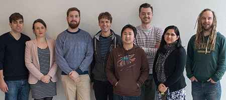

## JASP

**DEMO**

## rstanarm

## regressions in R

### classical

```r
require('datasets')
head(cars)
m1 = glm(speed ~ dist, data = cars)
```

### rstanarm

```r
require('rstanarm')
m2 = stan_glm(speed ~ dist, data = cars)
```

[check this [vignette](https://cran.r-project.org/web/packages/rstanarm/vignettes/rstanarm.html), and this [great tutorial paper](https://github.com/vasishth/BayesLMMTutorial/blob/master/doc/SorensenEtAl.pdf) for more]